# major_project

```python
for col in numeric_columns :
    Q1 = df[col].quantile(0.25)
    Q3 = df[col].quantile(0.75)

    IQR = Q3 - Q1

    lower_bound = Q1 - 1.5 * IQR
    upper_bound = Q3 + 1.5 * IQR

    outliers = df[(df[col] < lower_bound) | (df[col] > upper_bound)]

    print(f"\n{col}")
    print("Number of outliers:", len(outliers))
    print("Lower Bound:", lower_bound)
    print("Upper Bound:", upper_bound)
```

```
Farm_Area_Hectares
Number of outliers: 0
Lower Bound: -6.825000000000001
Upper Bound: 22.735

Rainfall_mm
Number of outliers: 0
Lower Bound: -326.9250000000001
Upper Bound: 1532.0750000000003

Avg_Temperature_C
Number of outliers: 2
Lower Bound: 15.349999999999994
Upper Bound: 38.150000000000006

Humidity_pct
Number of outliers: 6
Lower Bound: 29.087499999999988
Upper Bound: 97.58750000000002

Sunlight_Hours_Day
Number of outliers: 26
Lower Bound: 4.35
Upper Bound: 10.35

Soil_pH
Number of outliers: 0
Lower Bound: 4.9399999999999995
Upper Bound: 8.459999999999999

Soil_Moisture_pct
Number of outliers: 3
Lower Bound: 7.299999999999997
Upper Bound: 45.7

Nitrogen_kg_ha
Number of outliers: 10
Lower Bound: 34.41250000000001
Upper Bound: 205.3125

```

[output cut: 54 more lines]

```

Water_Used_m3
Number of outliers: 276
Lower Bound: -6072.75
Upper Bound: 16171.25

Water_Efficiency_t_per_1000m3
Number of outliers: 322
Lower Bound: -3.5728749999999994
Upper Bound: 10.384125

Disease_Pest_Risk_pct
Number of outliers: 10
Lower Bound: 10.899999999999995
Upper Bound: 81.3
```

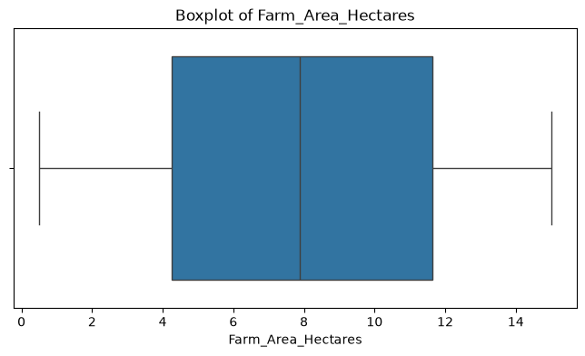

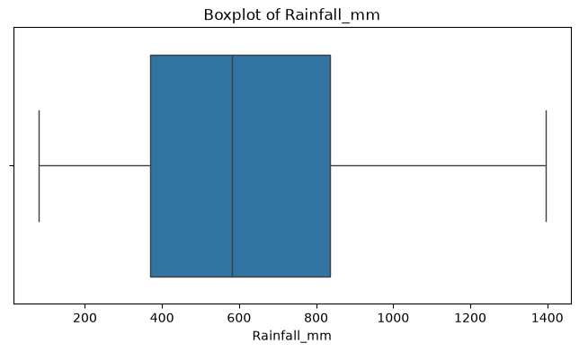

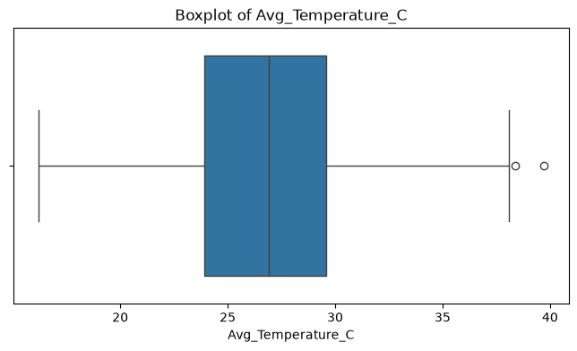

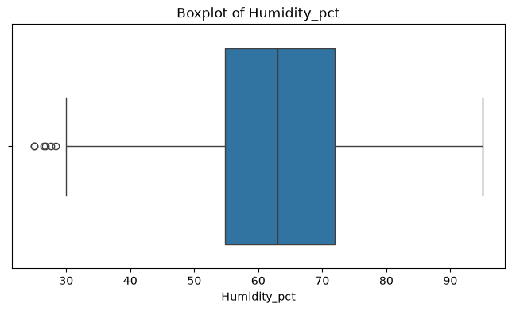

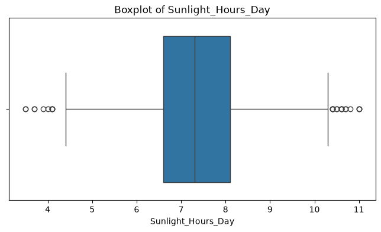

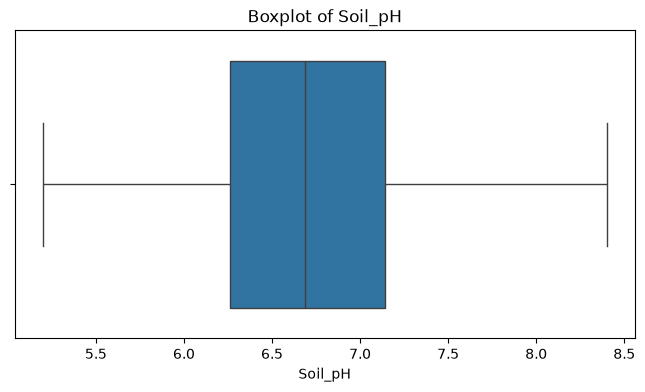

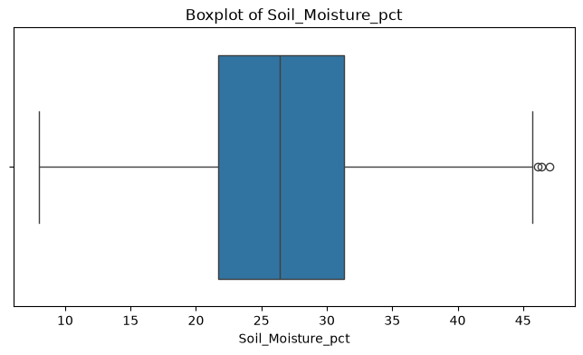

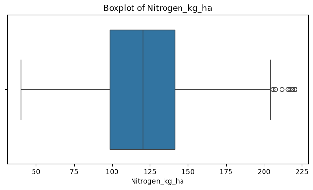

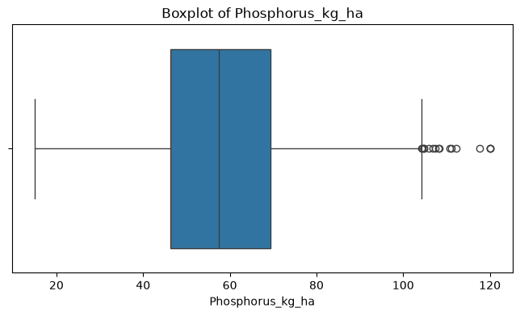

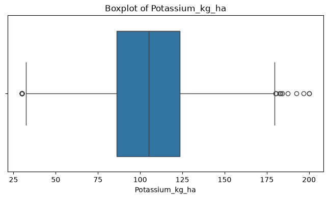

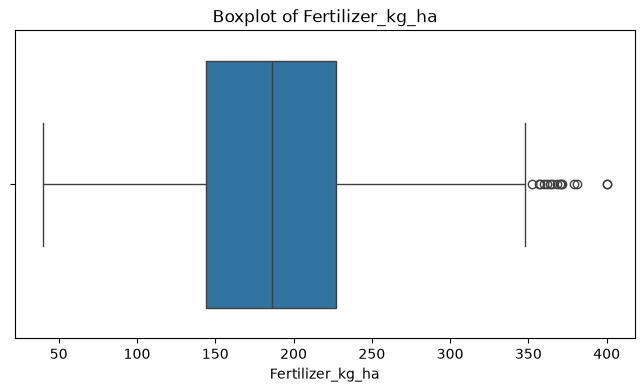

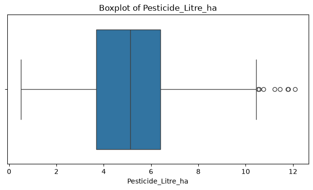

[10 more figures not shown]

```python
for col in numeric_columns:
    plt.figure(figsize=(8, 4))
    sns.boxplot(x=df[col])
    plt.title(f"Boxplot of {col}")
    plt.show()
```

```python
for col in numeric_columns:
    Q1 = df[col].quantile(0.25)
    Q3 = df[col].quantile(0.75)
    IQR = Q3 - Q1

    lower = Q1 - 1.5 * IQR
    upper = Q3 + 1.5 * IQR

    outliers = df[(df[col] < lower) | (df[col] > upper)]

    if len(outliers) > 0:
        print(f"\nOutliers in {col}:")
        print(outliers)
```

```
Outliers in Avg_Temperature_C:
      Farm_ID           State  District    Crop Season  Farm_Area_Hectares  \
585   SF10586       Telangana  Warangal  Cotton   Zaid               13.96
3026  SF13027  Madhya Pradesh    Rajkot   Wheat   Zaid                6.77

      Rainfall_mm  Avg_Temperature_C  Humidity_pct  Sunlight_Hours_Day  ...  \
585         496.6               39.7          54.4                 9.4  ...
3026        525.9               38.4          56.5                 7.4  ...

      Seed_Quality_Score  Yield_Tonnes_Ha  Production_Tonnes  \
585                 0.98             0.30               4.19
3026                0.84             2.61              17.67

      Market_Price_INR_Tonne  Total_Cost_INR Revenue_INR  Profit_INR  \
585                    47327         1094030      198300     -895730
```

[output cut: 1376 more lines]

```python
# Initialize an empty list to store outlier summaries
outlier_summary = []

for col in numeric_columns:
    # Calculate the first quartile (25th percentile)
    q1 = df[col].quantile(0.25)

    # Calculate the third quartile (75th percentile)
    q3 = df[col].quantile(0.75)

    # Calculate the Interquartile Range (IQR)
    iqr = q3 - q1

    # Define the lower and upper bounds for outliers
    lower = q1 - 1.5 * iqr
    upper = q3 + 1.5 * iqr


    count = ((df[col] < lower) | (df[col] > upper)).sum()

    # Append the statistics for the current column to the summary list
    outlier_summary.append({
        "Column": col,
        "Lower_Bound": lower,
        "Upper_Bound": upper,
        "Outlier_count": count,
        "Outlier_Percentage": round((count / len(df)) * 100, 2)
    })

outlier_summary = pd.DataFrame(outlier_summary).sort_values(
    "Outlier_count", ascending=False
)
print(outlier_summary)
```

```
                           Column    Lower_Bound   Upper_Bound  Outlier_count  \
18                     Profit_INR -696111.000000  7.635670e+05            404
14              Production_Tonnes     -23.982500  5.335750e+01            333
20  Water_Efficiency_t_per_1000m3      -3.572875  1.038412e+01            322
13                Yield_Tonnes_Ha      -1.620000  5.500000e+00            302
19                  Water_Used_m3   -6072.750000  1.617125e+04            276
17                    Revenue_INR -736519.000000  1.780911e+06            240
9                 Potassium_kg_ha      30.100000  1.797000e+02             32
4              Sunlight_Hours_Day       4.350000  1.035000e+01             26
8                Phosphorus_kg_ha      11.400000  1.042000e+02             16
10               Fertilizer_kg_ha      19.137500  3.520375e+02             15
7                  Nitrogen_kg_ha      34.412500  2.053125e+02             10
21          Disease_Pest_Risk_pct      10.900000  8.130000e+01             10
11             Pesticide_Litre_ha      -0.375000  1.046500e+01              8
3                    Humidity_pct      29.087500  9.758750e+01              6
```

[output cut: 32 more lines]

Bivariate Analysis: Bivariate analysis was performed to study the relationship between two variables. Scatter plots were used to analyze relationships between numerical variables, while box plots and bar charts were used to compare numerical variables across different categorical groups.

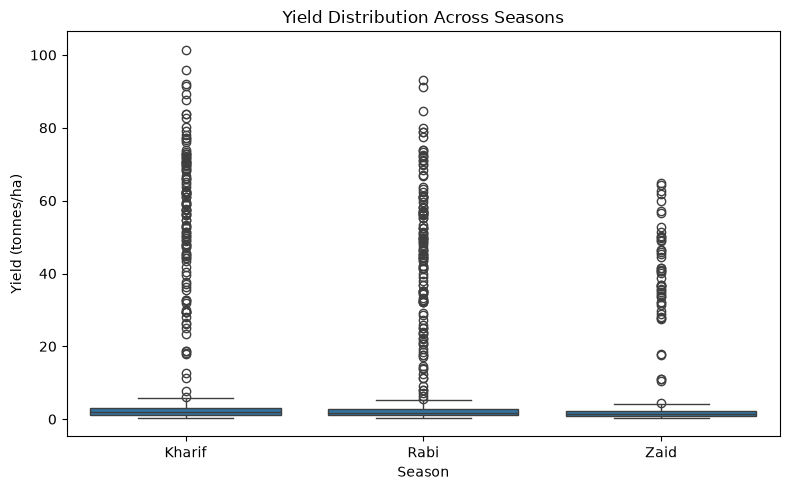

```python
# Bivariate: Season vs Yield

plt.figure(figsize=(8, 5))
sns.boxplot(data=df, x="Season", y="Yield_Tonnes_Ha")
plt.title("Yield Distribution Across Seasons")
plt.xlabel("Season")
plt.ylabel("Yield (tonnes/ha)")
plt.tight_layout()
plt.show()
```

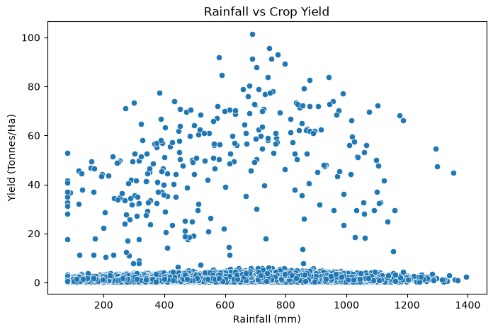

```python
plt.figure(figsize=(8,5))
sns.scatterplot(x='Rainfall_mm', y='Yield_Tonnes_Ha', data=df)
plt.title('Rainfall vs Crop Yield')
plt.xlabel('Rainfall (mm)')
plt.ylabel('Yield (Tonnes/Ha)')
plt.show()
```

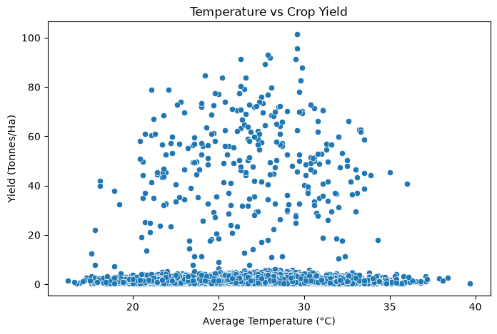

```python
plt.figure(figsize=(8,5))
sns.scatterplot(x='Avg_Temperature_C', y='Yield_Tonnes_Ha', data=df)
plt.title('Temperature vs Crop Yield')
plt.xlabel('Average Temperature (°C)')
plt.ylabel('Yield (Tonnes/Ha)')
plt.show()
```

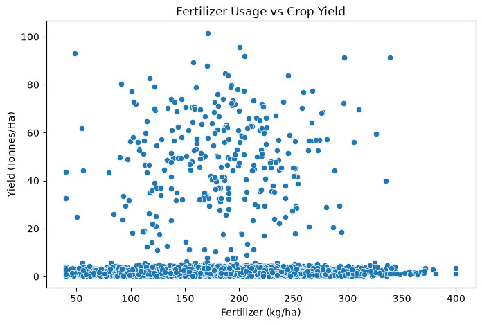

```python
plt.figure(figsize=(8,5))
sns.scatterplot(x='Fertilizer_kg_ha', y='Yield_Tonnes_Ha', data=df)
plt.title('Fertilizer Usage vs Crop Yield')
plt.xlabel('Fertilizer (kg/ha)')
plt.ylabel('Yield (Tonnes/Ha)')
plt.show()
```

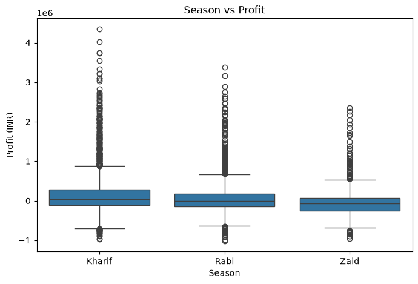

```python
plt.figure(figsize=(8,5))
sns.boxplot(x='Season', y='Profit_INR', data=df)
plt.title('Season vs Profit')
plt.xlabel('Season')
plt.ylabel('Profit (INR)')
plt.show()
```

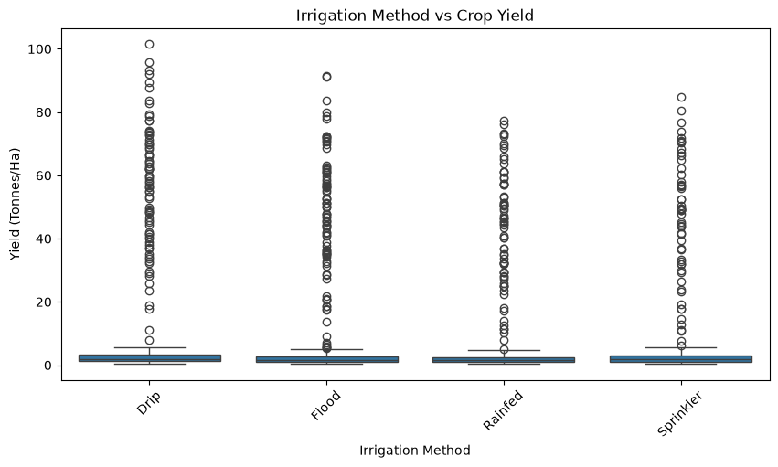

```python
plt.figure(figsize=(10,5))
sns.boxplot(x='Irrigation_Method', y='Yield_Tonnes_Ha', data=df)
plt.title('Irrigation Method vs Crop Yield')
plt.xlabel('Irrigation Method')
plt.ylabel('Yield (Tonnes/Ha)')
plt.xticks(rotation=45)
plt.show()
```

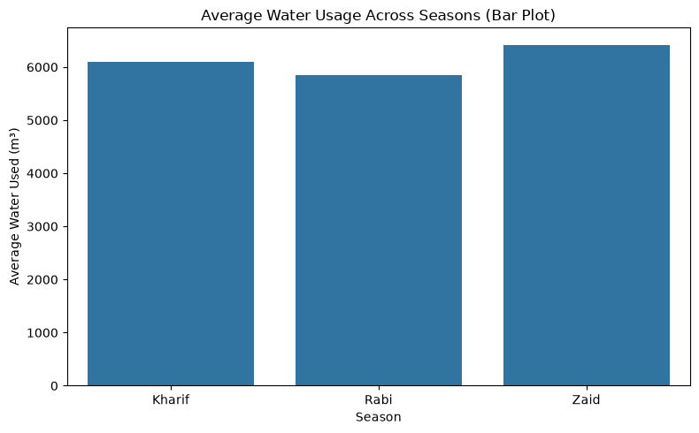

```python
plt.figure(figsize=(8, 5))
sns.barplot(data=df, x="Season", y="Water_Used_m3", errorbar=None)
plt.title("Average Water Usage Across Seasons (Bar Plot)")
plt.xlabel("Season")
plt.ylabel("Average Water Used (m³)")
plt.tight_layout()
plt.show()
```

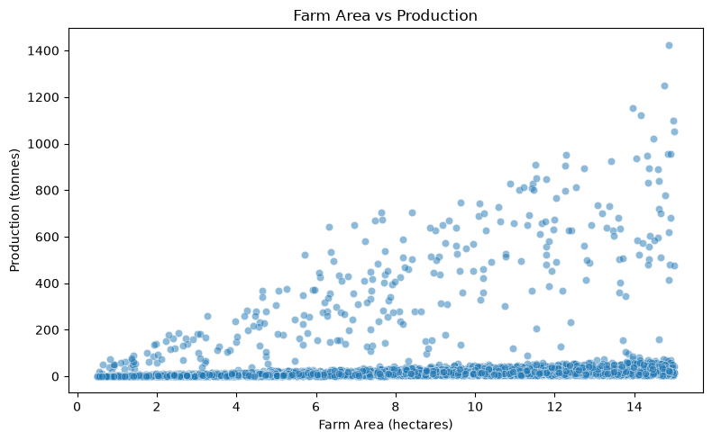

```python
# Bivariate: Farm area vs Production

plt.figure(figsize=(8, 5))
sns.scatterplot(data=df, x="Farm_Area_Hectares", y="Production_Tonnes", alpha=0.5)
plt.title("Farm Area vs Production")
plt.xlabel("Farm Area (hectares)")
plt.ylabel("Production (tonnes)")
plt.tight_layout()
plt.show()
```

[output not shown]

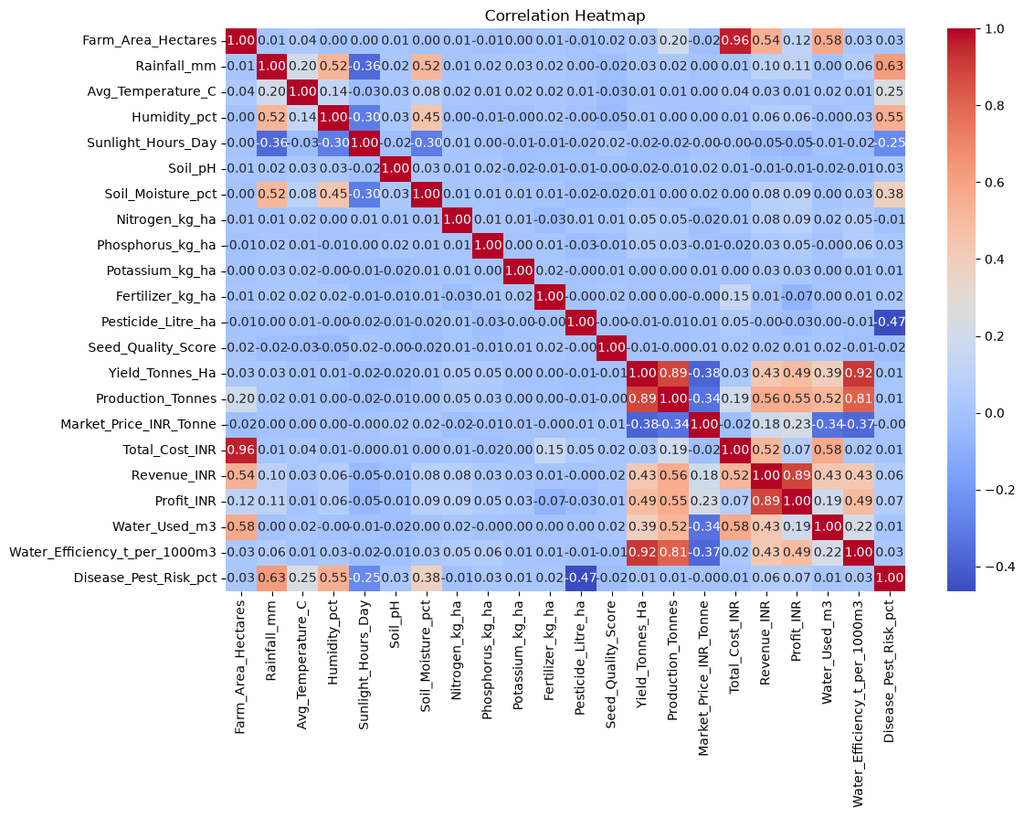

```python
plt.figure(figsize=(12,8))

corr = df.select_dtypes(include='number').corr()

sns.heatmap(corr, annot=True, cmap='coolwarm', fmt='.2f')

plt.title('Correlation Heatmap')
plt.show
```

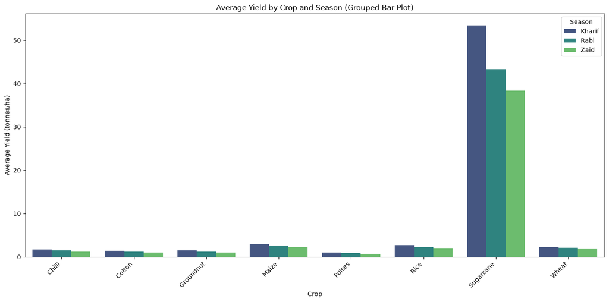

```python
#Create summary table
crop_season_summary = (
    df.groupby(["Crop", "Season"])["Yield_Tonnes_Ha"]
      .mean()
      .reset_index()
      .rename(columns={"Yield_Tonnes_Ha": "Average_Yield"})
)


plt.figure(figsize=(14, 7))


sns.barplot(
    data=crop_season_summary.reset_index(),
    x='Crop',
    y='Average_Yield',
    hue='Season',
    palette='viridis'
)

plt.title('Average Yield by Crop and Season (Grouped Bar Plot)')
plt.xlabel('Crop')
plt.ylabel('Average Yield (tonnes/ha)')


plt.xticks(rotation=45, ha='right')


plt.legend(title='Season')


plt.tight_layout()

# Display the chart
plt.show()
```

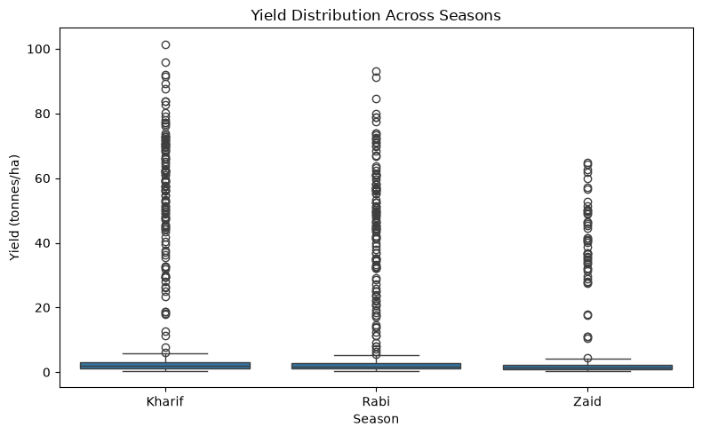

```python
# Bivariate: Season vs yield

plt.figure(figsize=(8, 5))
sns.boxplot(data=df, x="Season", y="Yield_Tonnes_Ha")
plt.title("Yield Distribution Across Seasons")
plt.xlabel("Season")
plt.ylabel("Yield (tonnes/ha)")
plt.tight_layout()
```

```python
columns_to_analyze = [
    'Farm_Area_Hectares',
    'Rainfall_mm',
    'Soil_pH',
    'Seed_Quality_Score',
    'Total_Cost_INR',
    'Market_Price_INR_Tonne'
]

summary_df = pd.DataFrame({
    'Feature': columns_to_analyze,
    'Min': [df[col].min() for col in columns_to_analyze],
    'Max': [df[col].max() for col in columns_to_analyze],
    'Null_Count': [df[col].isnull().sum() for col in columns_to_analyze],
    'Zero_Count': [(df[col] == 0).sum() for col in columns_to_analyze]
})

print(summary_df)
```

```
                  Feature       Min        Max  Null_Count  Zero_Count
0      Farm_Area_Hectares      0.50       15.0           0           0
1             Rainfall_mm     80.00     1395.2           0           0
2                 Soil_pH      5.20        8.4           0           0
3      Seed_Quality_Score      0.65        1.0           0           0
4          Total_Cost_INR  26826.00  1349990.0           0           0
5  Market_Price_INR_Tonne   2594.00   131240.0           0           0
```

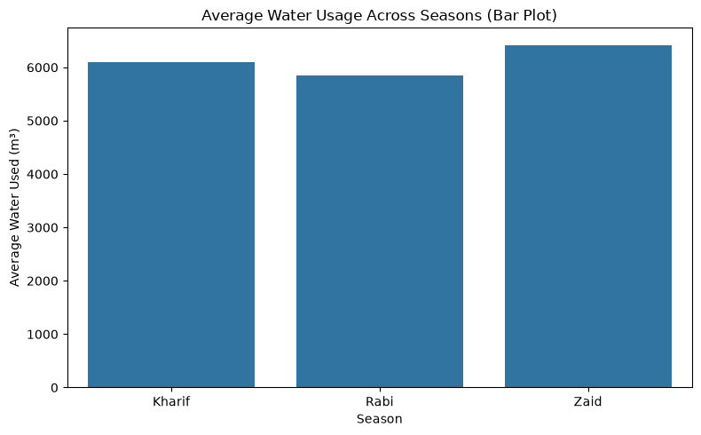

```python
plt.figure(figsize=(8, 5))
sns.barplot(data=df, x="Season", y="Water_Used_m3", errorbar=None)
plt.title("Average Water Usage Across Seasons (Bar Plot)")
plt.xlabel("Season")
plt.ylabel("Average Water Used (m³)")
plt.tight_layout()
plt.show()
```

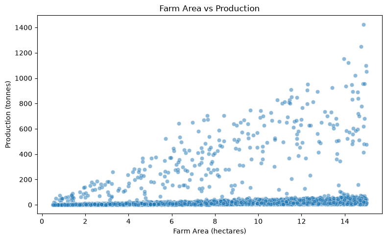

```python
# Bivariate: Farm area vs Production

plt.figure(figsize=(8, 5))
sns.scatterplot(data=df, x="Farm_Area_Hectares", y="Production_Tonnes", alpha=0.5)
plt.title("Farm Area vs Production")
plt.xlabel("Farm Area (hectares)")
plt.ylabel("Production (tonnes)")
plt.tight_layout()
plt.show()
```

Multivariate Analysis: Multivariate analysis was performed to study the combined relationship between multiple agricultural factors such as rainfall, temperature, fertilizer usage, irrigation method, crop type, season, yield, production, revenue, and profit. Heatmaps, scatter plots, boxplots, bar charts, and pairplots were used to identify patterns and understand how multiple factors influence agricultural performance.

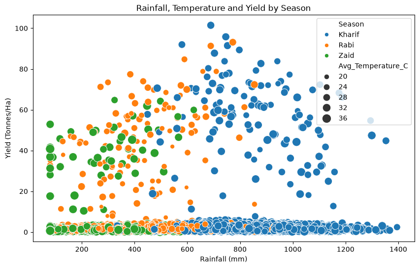

```python
plt.figure(figsize=(10, 6))

sns.scatterplot(
    data=df,
    x='Rainfall_mm',
    y='Yield_Tonnes_Ha',
    hue='Season',
    size='Avg_Temperature_C',
    sizes=(30, 200)
)

plt.title('Rainfall, Temperature and Yield by Season')
plt.xlabel('Rainfall (mm)')
plt.ylabel('Yield (Tonnes/Ha)')
plt.show()
```

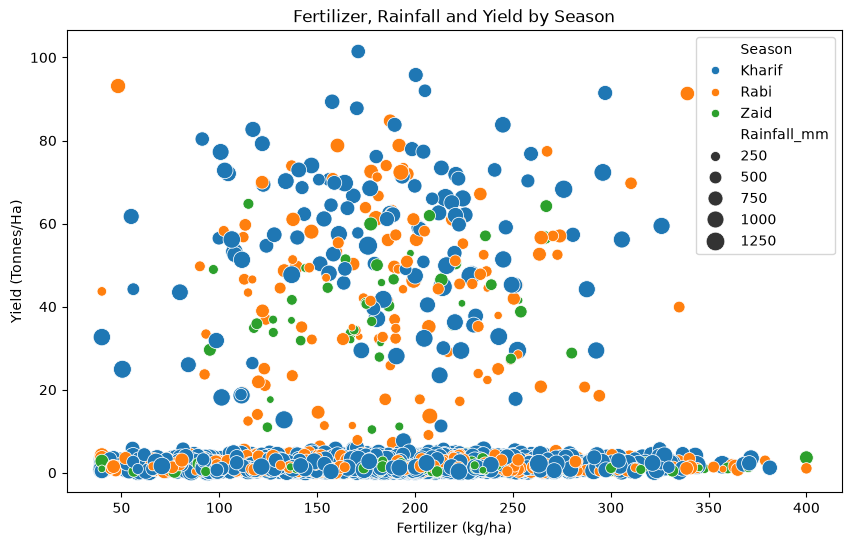

```python
plt.figure(figsize=(10, 6))

sns.scatterplot(
    data=df,
    x='Fertilizer_kg_ha',
    y='Yield_Tonnes_Ha',
    hue='Season',
    size='Rainfall_mm',
    sizes=(30, 200)
)

plt.title('Fertilizer, Rainfall and Yield by Season')
plt.xlabel('Fertilizer (kg/ha)')
plt.ylabel('Yield (Tonnes/Ha)')
plt.show()
```

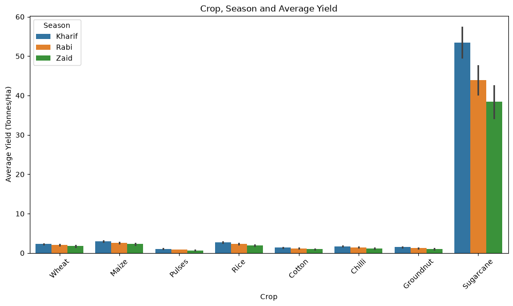

```python
plt.figure(figsize=(12, 6))

sns.barplot(
    data=df,
    x='Crop',
    y='Yield_Tonnes_Ha',
    hue='Season'
)

plt.title('Crop, Season and Average Yield')
plt.xlabel('Crop')
plt.ylabel('Average Yield (Tonnes/Ha)')
plt.xticks(rotation=45)
plt.show()
```

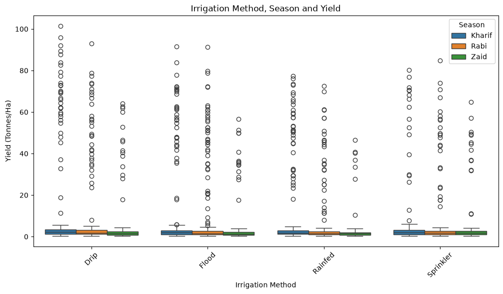

```python
plt.figure(figsize=(12, 6))

sns.boxplot(
    data=df,
    x='Irrigation_Method',
    y='Yield_Tonnes_Ha',
    hue='Season'
)

plt.title('Irrigation Method, Season and Yield')
plt.xlabel('Irrigation Method')
plt.ylabel('Yield (Tonnes/Ha)')
plt.xticks(rotation=45)
plt.show()
```

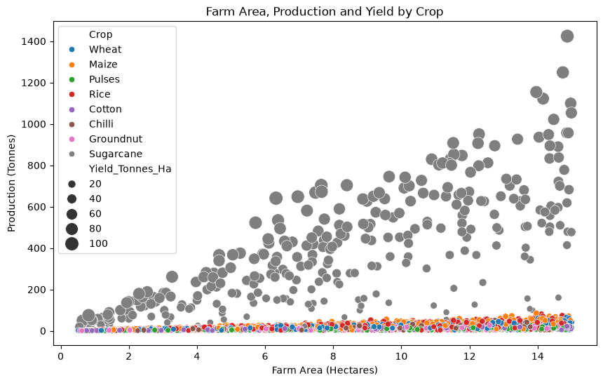

```python
plt.figure(figsize=(10, 6))

sns.scatterplot(
    data=df,
    x='Farm_Area_Hectares',
    y='Production_Tonnes',
    hue='Crop',
    size='Yield_Tonnes_Ha',
    sizes=(30, 200)
)

plt.title('Farm Area, Production and Yield by Crop')
plt.xlabel('Farm Area (Hectares)')
plt.ylabel('Production (Tonnes)')
plt.show()
```

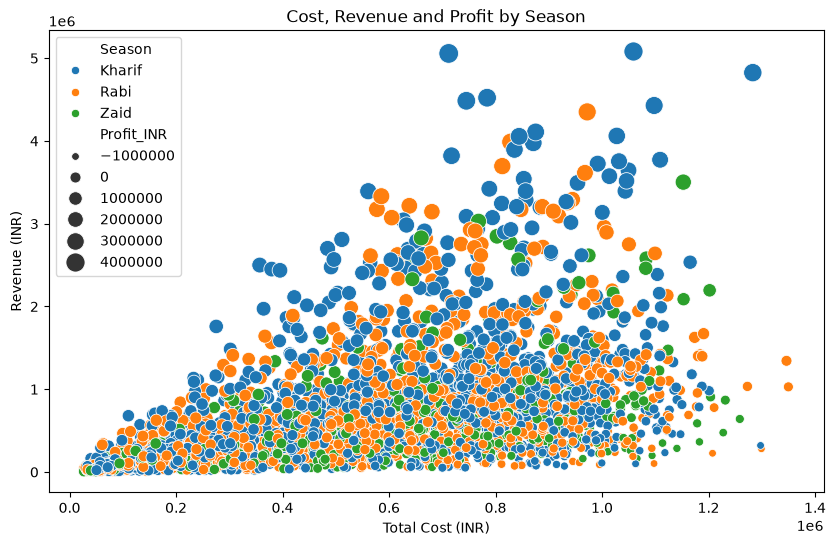

```python
plt.figure(figsize=(10, 6))

sns.scatterplot(
    data=df,
    x='Total_Cost_INR',
    y='Revenue_INR',
    hue='Season',
    size='Profit_INR',
    sizes=(30, 200)
)

plt.title('Cost, Revenue and Profit by Season')
plt.xlabel('Total Cost (INR)')
plt.ylabel('Revenue (INR)')
plt.show()
```

```python
crop_season_profit = df.groupby(
    ['Crop', 'Season']
)['Profit_INR'].mean().reset_index()

print(crop_season_profit)
```

```
         Crop  Season    Profit_INR
0      Chilli  Kharif  9.543804e+05
1      Chilli    Rabi  6.385725e+05
2      Chilli    Zaid  4.486591e+05
3      Cotton  Kharif  2.169995e+05
4      Cotton    Rabi  1.073436e+05
5      Cotton    Zaid -5.392534e+04
6   Groundnut  Kharif  1.082654e+05
7   Groundnut    Rabi  1.041654e+04
8   Groundnut    Zaid -6.887250e+04
9       Maize  Kharif -3.933267e+04
10      Maize    Rabi -8.913340e+04
11      Maize    Zaid -1.940492e+05
12     Pulses  Kharif  4.333890e+04
13     Pulses    Rabi -1.430914e+04
14     Pulses    Zaid -1.392278e+05
15       Rice  Kharif -6.490340e+04
16       Rice    Rabi -9.842787e+04
17       Rice    Zaid -2.272393e+05
18  Sugarcane  Kharif  1.000791e+06
19  Sugarcane    Rabi  7.316129e+05
20  Sugarcane    Zaid  5.836358e+05
21      Wheat  Kharif -1.058719e+05
22      Wheat    Rabi -1.199546e+05
23      Wheat    Zaid -1.932090e+05
```

```python
season_analysis = df.groupby('Season')[
    [
        'Rainfall_mm',
        'Avg_Temperature_C',
        'Fertilizer_kg_ha',
        'Yield_Tonnes_Ha',
        'Production_Tonnes',
        'Profit_INR'
    ]
].mean()

print(season_analysis)
```

```
        Rainfall_mm  Avg_Temperature_C  Fertilizer_kg_ha  Yield_Tonnes_Ha  \
Season
Kharif   852.084205          28.454019        187.077965         5.643973
Rabi     436.000124          23.489183        185.407068         5.080498
Zaid     299.421784          31.042088        184.638047         4.665942

        Production_Tonnes     Profit_INR
Season
Kharif          46.311192  178914.647555
Rabi            41.486712   87689.470191
Zaid            38.886111  -24804.824916
```

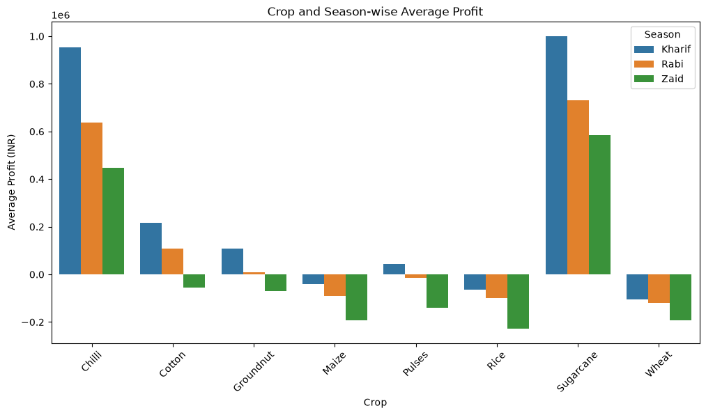

```python
plt.figure(figsize=(12, 6))

sns.barplot(
    data=crop_season_profit,
    x='Crop',
    y='Profit_INR',
    hue='Season'
)

plt.title('Crop and Season-wise Average Profit')
plt.xlabel('Crop')
plt.ylabel('Average Profit (INR)')
plt.xticks(rotation=45)
plt.show()
```

Correlation Analysis: Correlation analysis was performed to identify the strength and direction of linear relationships among numerical agricultural variables. A correlation matrix and heatmap were used to examine relationships between rainfall, temperature, fertilizer usage, yield, production, revenue, cost, and profit. This helps identify variables that have stronger associations with crop performance and profitability.

```python
# Select numerical columns
numeric_df = df.select_dtypes(include='number')

# Calculate correlation
correlation = numeric_df.corr()

print(correlation)
```

```
                               Farm_Area_Hectares  Rainfall_mm  \
Farm_Area_Hectares                       1.000000     0.007384
Rainfall_mm                              0.007384     1.000000
Avg_Temperature_C                        0.036870     0.200020
Humidity_pct                             0.000471     0.523966
Sunlight_Hours_Day                       0.001821    -0.364748
Soil_pH                                  0.009857     0.016742
Soil_Moisture_pct                        0.004079     0.515751
Nitrogen_kg_ha                           0.013658     0.007620
Phosphorus_kg_ha                        -0.006625     0.021175
Potassium_kg_ha                          0.000195     0.031655
Fertilizer_kg_ha                         0.014975     0.024610
Pesticide_Litre_ha                      -0.005207     0.004043
Seed_Quality_Score                       0.015236    -0.018789
Yield_Tonnes_Ha                          0.030188     0.030853
Production_Tonnes                        0.197842     0.024551
Market_Price_INR_Tonne                  -0.021571     0.000525
Total_Cost_INR                           0.962211     0.013173
Revenue_INR                              0.543364     0.098652
Profit_INR                               0.115241     0.108104
Water_Used_m3                            0.576015     0.002324
Water_Efficiency_t_per_1000m3            0.028930     0.058473
Disease_Pest_Risk_pct                    0.025963     0.625071

                               Avg_Temperature_C  Humidity_pct  \
Farm_Area_Hectares                      0.036870      0.000471
Rainfall_mm                             0.200020      0.523966
Avg_Temperature_C                       1.000000      0.138136
Humidity_pct                            0.138136      1.000000
Sunlight_Hours_Day                     -0.033863     -0.297298
Soil_pH                                 0.029988      0.028447
Soil_Moisture_pct                       0.084492      0.448717
Nitrogen_kg_ha                          0.018707      0.001198
Phosphorus_kg_ha                        0.008508     -0.005963
Potassium_kg_ha                         0.022993     -0.003070
Fertilizer_kg_ha                        0.015861      0.024623
Pesticide_Litre_ha                      0.006657     -0.004028
Seed_Quality_Score                     -0.031943     -0.045598
Yield_Tonnes_Ha                         0.009349      0.011277
Production_Tonnes                       0.007346      0.003614
```

[output cut: 186 more lines]

```
Potassium_kg_ha                             0.013403
Fertilizer_kg_ha                            0.017851
Pesticide_Litre_ha                         -0.465183
Seed_Quality_Score                         -0.024602
Yield_Tonnes_Ha                             0.013490
Production_Tonnes                           0.013961
Market_Price_INR_Tonne                     -0.000454
Total_Cost_INR                              0.005922
Revenue_INR                                 0.060571
Profit_INR                                  0.067583
Water_Used_m3                               0.011485
Water_Efficiency_t_per_1000m3               0.029253
Disease_Pest_Risk_pct                       1.000000

[22 rows x 22 columns]
```

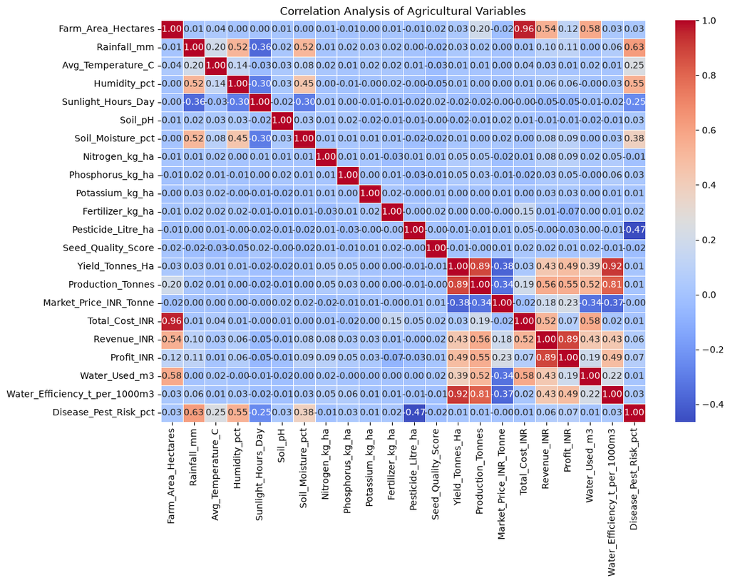

```python
plt.figure(figsize=(12, 8))

sns.heatmap(
    correlation,
    annot=True,
    cmap='coolwarm',
    fmt='.2f',
    linewidths=0.5
)

plt.title('Correlation Analysis of Agricultural Variables')
plt.show()
```

```python
yield_corr = df.select_dtypes(include='number').corr()['Yield_Tonnes_Ha'].sort_values(
    ascending=False
)

print(yield_corr)
```

```
Yield_Tonnes_Ha                  1.000000
Water_Efficiency_t_per_1000m3    0.915438
Production_Tonnes                0.885171
Profit_INR                       0.489822
Revenue_INR                      0.433648
Water_Used_m3                    0.388653
Nitrogen_kg_ha                   0.053867
Phosphorus_kg_ha                 0.047821
Rainfall_mm                      0.030853
Total_Cost_INR                   0.030814
Farm_Area_Hectares               0.030188
Disease_Pest_Risk_pct            0.013490
Humidity_pct                     0.011277
Soil_Moisture_pct                0.010210
Avg_Temperature_C                0.009349
Potassium_kg_ha                  0.003836
Fertilizer_kg_ha                 0.000562
Seed_Quality_Score              -0.006737
Pesticide_Litre_ha              -0.007650
Sunlight_Hours_Day              -0.015362
Soil_pH                         -0.020664
Market_Price_INR_Tonne          -0.384307
Name: Yield_Tonnes_Ha, dtype: float64
```

```python
profit_corr = df.select_dtypes(include='number').corr()['Profit_INR'].sort_values(
    ascending=False
)

print(profit_corr)
```

```
Profit_INR                       1.000000
Revenue_INR                      0.887331
Production_Tonnes                0.554172
Yield_Tonnes_Ha                  0.489822
Water_Efficiency_t_per_1000m3    0.489487
Market_Price_INR_Tonne           0.225119
Water_Used_m3                    0.190278
Farm_Area_Hectares               0.115241
Rainfall_mm                      0.108104
Soil_Moisture_pct                0.091757
Nitrogen_kg_ha                   0.085016
Total_Cost_INR                   0.068356
Disease_Pest_Risk_pct            0.067583
Humidity_pct                     0.063775
Phosphorus_kg_ha                 0.049747
Potassium_kg_ha                  0.031192
Seed_Quality_Score               0.010438
Avg_Temperature_C                0.009043
Soil_pH                         -0.013145
Pesticide_Litre_ha              -0.025705
Sunlight_Hours_Day              -0.054822
Fertilizer_kg_ha                -0.073542
Name: Profit_INR, dtype: float64
```

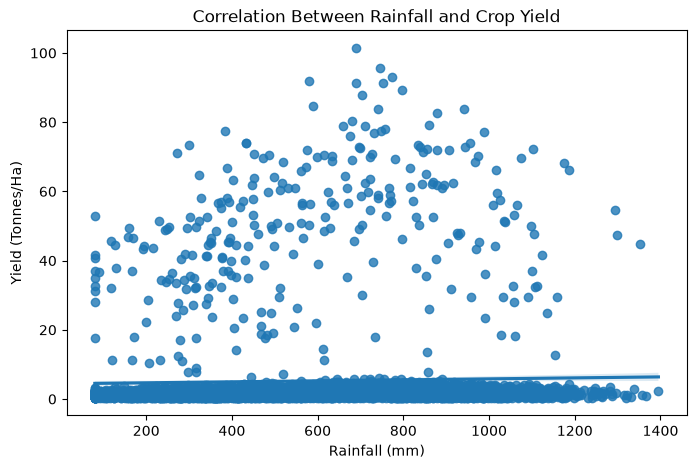

```python
plt.figure(figsize=(8, 5))

sns.regplot(
    data=df,
    x='Rainfall_mm',
    y='Yield_Tonnes_Ha'
)

plt.title('Correlation Between Rainfall and Crop Yield')
plt.xlabel('Rainfall (mm)')
plt.ylabel('Yield (Tonnes/Ha)')
plt.show()
```

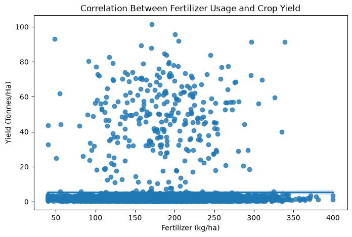

```python
plt.figure(figsize=(8, 5))

sns.regplot(
    data=df,
    x='Fertilizer_kg_ha',
    y='Yield_Tonnes_Ha'
)

plt.title('Correlation Between Fertilizer Usage and Crop Yield')
plt.xlabel('Fertilizer (kg/ha)')
plt.ylabel('Yield (Tonnes/Ha)')
plt.show()
```

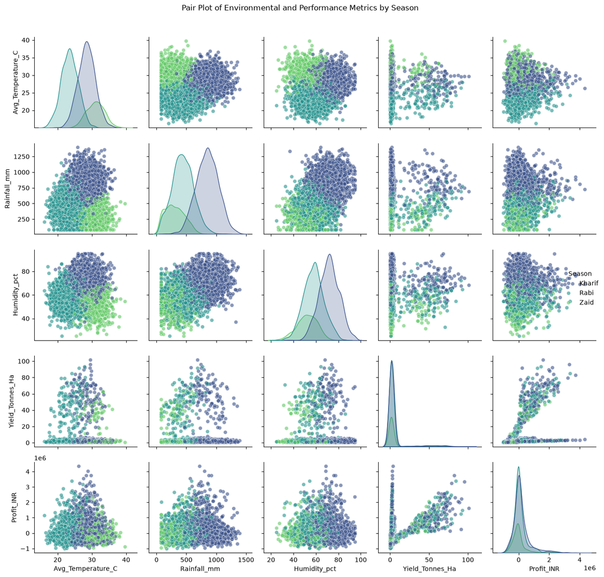

```python
# Define the columns to include in the pair plot
selected_columns = [
    "Avg_Temperature_C",
    "Rainfall_mm",
    "Humidity_pct",
    "Yield_Tonnes_Ha",
    "Profit_INR",
    "Season",
]

# Create the pair plot grouped by 'Season'
sns.pairplot(
    df[selected_columns], hue="Season", palette="viridis", plot_kws={"alpha": 0.6}
)

# Add the main title and adjust layout
plt.suptitle(
    "Pair Plot of Environmental and Performance Metrics by Season", y=1.02
)  # Adjust suptitle position
plt.tight_layout()
plt.show()
```

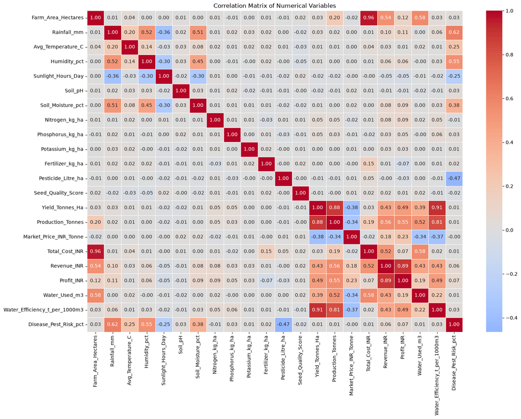

```python
# Correlation heatmap for numerical variables

plt.figure(figsize=(16, 12))
corr = df[numeric_columns].corr(numeric_only=True)

sns.heatmap(
    corr,
    annot=True,
    fmt=".2f",
    cmap="coolwarm",
    center=0,
    linewidths=0.5
)

plt.title("Correlation Matrix of Numerical Variables")
plt.tight_layout()
```

```python
# Recreating the exact dataset from your Google Colab screen
data = {
    "Season": ["Zaid"] * 14,
    "Crop": [
        "Rice", "Wheat", "Chilli", "Groundnut", "Cotton", "Pulses", "Sugarcane",
        "Maize", "Rice", "Wheat", "Chilli", "Groundnut", "Cotton", "Pulses"
    ],
    "Value_1": [2.32, 2.06, 1.47, 1.23, 1.20, 0.88, 38.42, 2.29, 1.90, 1.75, 1.20, 1.04, 0.96, 0.67],
    "Value_2": [
        -98427.87, -119954.57, 638572.50, 10416.54, 107343.59, -14309.14, 583635.80,
        -194049.17, -227239.34, -193208.95, 448659.09, -68872.50, -53925.34, -139227.81
    ],
    "Value_3": [1.84, 4.69, 2.89, 2.90, 1.94, 2.70, 23.39, 4.75, 1.53, 4.02, 2.20, 2.47, 1.49, 1.95]
}

# Create DataFrame
df = pd.DataFrame(data)

# Set up column names if you want to explicitly title them (e.g., Yield, Production, Area)
df.columns = ["Season", "Crop", "Metric_1", "Metric_2", "Metric_3"]

# Display the full DataFrame
print(df)
```

```
   Season       Crop  Metric_1   Metric_2  Metric_3
0    Zaid       Rice      2.32  -98427.87      1.84
1    Zaid      Wheat      2.06 -119954.57      4.69
2    Zaid     Chilli      1.47  638572.50      2.89
3    Zaid  Groundnut      1.23   10416.54      2.90
4    Zaid     Cotton      1.20  107343.59      1.94
5    Zaid     Pulses      0.88  -14309.14      2.70
6    Zaid  Sugarcane     38.42  583635.80     23.39
7    Zaid      Maize      2.29 -194049.17      4.75
8    Zaid       Rice      1.90 -227239.34      1.53
9    Zaid      Wheat      1.75 -193208.95      4.02
10   Zaid     Chilli      1.20  448659.09      2.20
11   Zaid  Groundnut      1.04  -68872.50      2.47
12   Zaid     Cotton      0.96  -53925.34      1.49
13   Zaid     Pulses      0.67 -139227.81      1.95
```

Seasonal Comparisons: Seasonal comparisons were performed to evaluate how agricultural performance varies across different seasons. Average rainfall, temperature, fertilizer usage, crop yield, production, revenue, and profit were compared using statistical summaries and visualizations. This analysis helps identify which seasons provide better agricultural productivity and profitability.

```python
season_yield = df.groupby('Season')['Yield_Tonnes_Ha'].mean()
print(season_yield)
```

[output not shown]

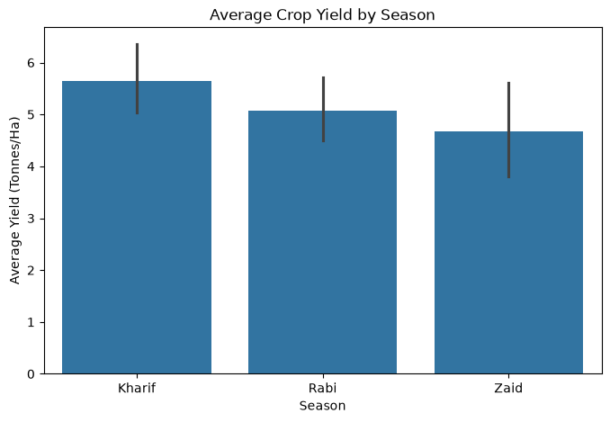

```python
plt.figure(figsize=(8, 5))

sns.barplot(
    data=df,
    x='Season',
    y='Yield_Tonnes_Ha'
)

plt.title('Average Crop Yield by Season')
plt.xlabel('Season')
plt.ylabel('Average Yield (Tonnes/Ha)')
plt.show()
```

```python
season_production = df.groupby('Season')['Production_Tonnes'].mean()

print(season_production)
```

[output not shown]

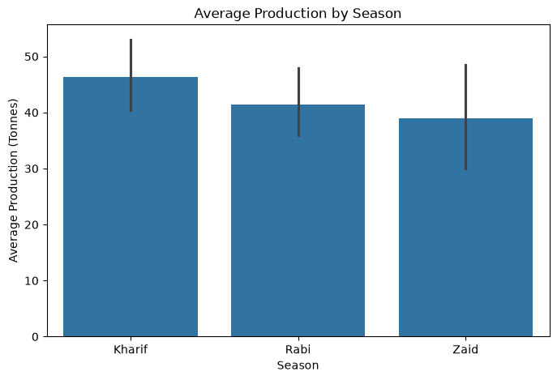

```python
plt.figure(figsize=(8, 5))

sns.barplot(
    data=df,
    x='Season',
    y='Production_Tonnes'
)

plt.title('Average Production by Season')
plt.xlabel('Season')
plt.ylabel('Average Production (Tonnes)')
plt.show()
```

```python
season_profit = df.groupby('Season')['Profit_INR'].mean()

print(season_profit)
```

[output not shown]

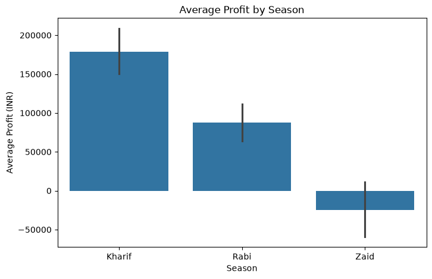

```python
plt.figure(figsize=(8, 5))

sns.barplot(
    data=df,
    x='Season',
    y='Profit_INR'
)

plt.title('Average Profit by Season')
plt.xlabel('Season')
plt.ylabel('Average Profit (INR)')
plt.show()
```

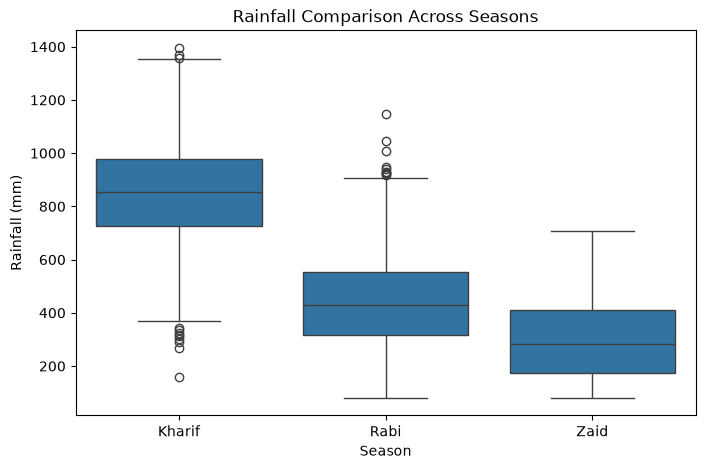

```python
plt.figure(figsize=(8, 5))

sns.boxplot(
    data=df,
    x='Season',
    y='Rainfall_mm'
)

plt.title('Rainfall Comparison Across Seasons')
plt.xlabel('Season')
plt.ylabel('Rainfall (mm)')
plt.show()
```

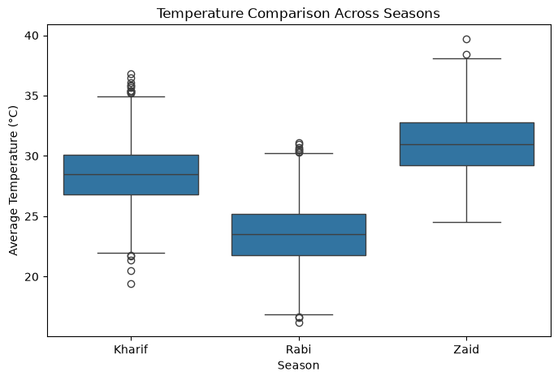

```python
plt.figure(figsize=(8, 5))

sns.boxplot(
    data=df,
    x='Season',
    y='Avg_Temperature_C'
)

plt.title('Temperature Comparison Across Seasons')
plt.xlabel('Season')
plt.ylabel('Average Temperature (°C)')
plt.show()
```

```python
season_summary = df.groupby('Season')[
    [
        'Rainfall_mm',
        'Avg_Temperature_C',
        'Fertilizer_kg_ha',
        'Yield_Tonnes_Ha',
        'Production_Tonnes',
        'Revenue_INR',
        'Profit_INR'
    ]
].mean()

print(season_summary)
```

```
        Rainfall_mm  Avg_Temperature_C  Fertilizer_kg_ha  Yield_Tonnes_Ha  \
Season
Kharif   852.084205          28.454019        187.077965         5.643973
Rabi     436.000124          23.489183        185.407068         5.080498
Zaid     299.421784          31.042088        184.638047         4.665942

        Production_Tonnes    Revenue_INR     Profit_INR
Season
Kharif          46.311192  710719.055649  178914.647555
Rabi            41.486712  601526.048556   87689.470191
Zaid            38.886111  519171.904040  -24804.824916
```

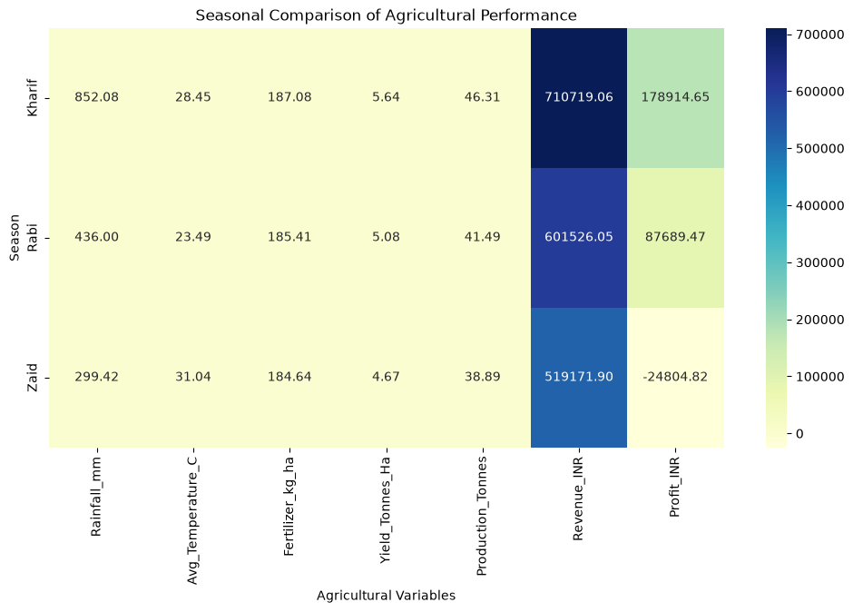

```python
plt.figure(figsize=(12, 6))

sns.heatmap(
    season_summary,
    annot=True,
    fmt='.2f',
    cmap='YlGnBu'
)

plt.title('Seasonal Comparison of Agricultural Performance')
plt.xlabel('Agricultural Variables')
plt.ylabel('Season')
plt.show()
```

```python
crop_season = df.groupby(
    ['Crop', 'Season']
)['Yield_Tonnes_Ha'].mean().reset_index()

print(crop_season)
```

```
         Crop  Season  Yield_Tonnes_Ha
0      Chilli  Kharif         1.731413
1      Chilli    Rabi         1.461615
2      Chilli    Zaid         1.177742
3      Cotton  Kharif         1.372804
4      Cotton    Rabi         1.192915
5      Cotton    Zaid         0.951648
6   Groundnut  Kharif         1.483646
7   Groundnut    Rabi         1.221445
8   Groundnut    Zaid         1.037778
9       Maize  Kharif         2.966410
10      Maize    Rabi         2.614913
11      Maize    Zaid         2.297590
12     Pulses  Kharif         1.036063
13     Pulses    Rabi         0.871887
14     Pulses    Zaid         0.652131
15       Rice  Kharif         2.707621
16       Rice    Rabi         2.333680
17       Rice    Zaid         1.900490
18  Sugarcane  Kharif        53.459120
19  Sugarcane    Rabi        43.940394
20  Sugarcane    Zaid        38.423922
21      Wheat  Kharif         2.255430
22      Wheat    Rabi         2.058814
23      Wheat    Zaid         1.748588
```